# Hazardous Driving Analysis

Brandon Terrizzi, Ph.D.

12/29/2020

## Background

In this brief, exploratory analysis I investigate locations with high rates of hazardous driving as reported in this particular dataset.

## Preliminary Analyses: Which countries exhibit the highest frequency of hazardous driving in this data set?

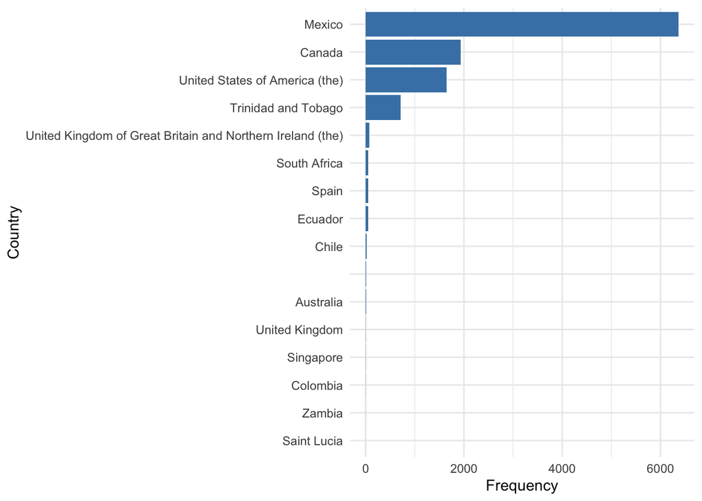

The data is overwhelming comprised of info about Mexico so let’s focus there.

## Mexico

Since we are trying to identify which *cities* have the most hazardous driving, we will omit data that is missing city-level information. We will first summarize and visualize hazardous driving at the state-level. Then, we will zoom into the city-level data from there.

Let’s have a look at how the metrics about incident numbers and severity are distributed by state across the entire country of Mexcio.

### Incidents and Severity: State-Level Visualization

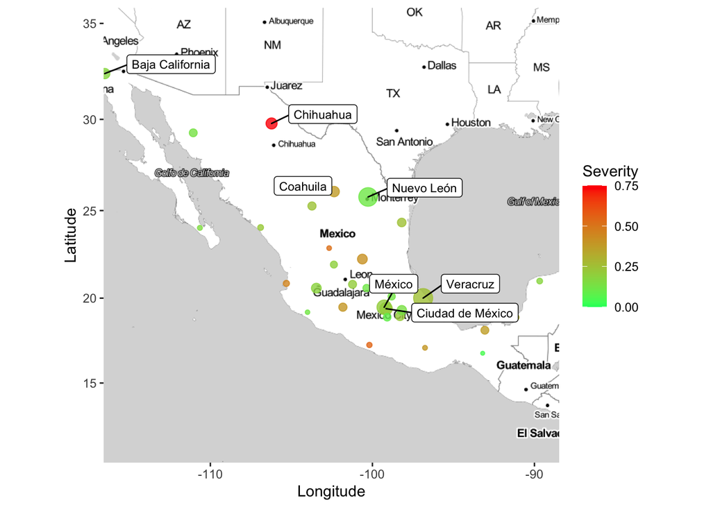

Labels are applied to states with more than 500 incidents of hazardous driving.

Veracruz is looking like a mild bumper car ride and Chihuahua is looking like a hot bed of severity. Let’s dig in to these states and learn more about what is going on there.

### Foucs on Incidents in the state of Veracruz

There are many cities in Veracruz. How are incidents distributed across them?

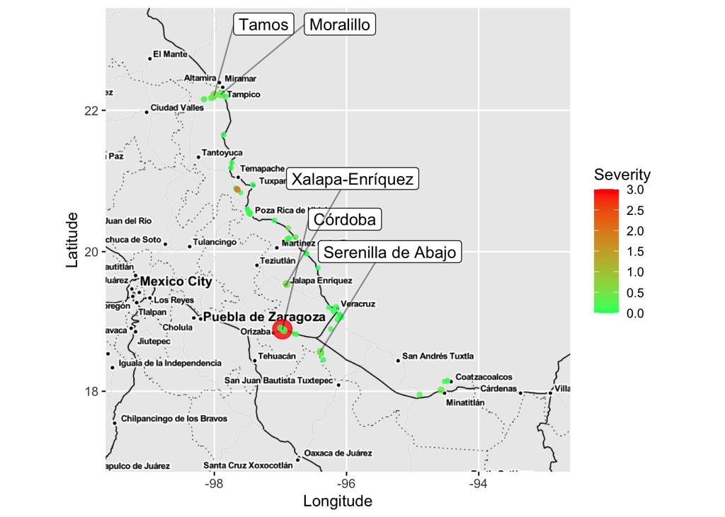

Cordoba is the city with both the greatest number of incidents and those with highest severity.

### Focus on Severity within the State of Chihuaha

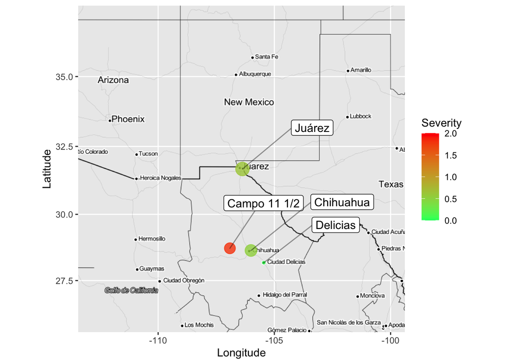

What is this “Campo 11 1/2” and why is it such a hot bed of hazardous driving activity? Our data do not allow us to explore this specific question, but we will want to make sure to develop interventions in this area.

## Conclusion

The data analyzed here suggest that within Mexico, Cordoba in the state of Veracruz has the highest number of hazardous driving incidents, while the state of Chihuaha exhibits the highest average severity of hazardous driving incidents. It is not clear from this data whether these patterns reflect real-world patterns of hazardous driving, reporting patterns in different countries or regions, or some combination of these factors.